# Alzheimers Disease Brain Blood Samples

```r
h2o.removeAll() ## clean slate - just in case the cluster was already running

D = h2o.importFile(path = normalizePath("hemochromatosis_ML_ready.csv"))
#h2o.summary(D) would print the summary stats of these 251 features

data = h2o.splitFrame(D,ratios=c(.7,.15),
                      destination_frames = c("train","test","valid"))
names(data) <- c('Train','Test','Valid')
```

multinomial model

```r
m1 = h2o.glm(training_frame = data$Train, validation_frame = data$Valid,
             x = colnames(data$Train)[2:74],
             y = 'Class_Type',
             family='multinomial',
             solver='L_BFGS')
h2o.confusionMatrix(m1, valid=TRUE)
```

|  | AD Female | AD Healthy Female | AD Healthy Male | AD Male | Flu Immunized Only Day 1 | Flu Immunized Only Day 21 | Flu Immunized Only Day 3 | Flu Immunized Only Day 7 | Flu Immunized Plus Antibiotics Day 1 | Flu Immunized Plus Antibiotics Day 21 | Flu Immunized Plus Antibiotics Day 3 | Flu Immunized Plus Antibiotics Day 7 | Flu non immunized healthy | Hemo Female | Hemo Healthy Female | Hemo Healthy Male | Hemo Male | MI Healthy Males | MI Males | Overweight Female | Overweight Female EGCG Treated | Overweight Female EGCG+fishOil+VitC | Tetanis Immunized | Error | Rate |
| --- | --- | --- | --- | --- | --- | --- | --- | --- | --- | --- | --- | --- | --- | --- | --- | --- | --- | --- | --- | --- | --- | --- | --- | --- | --- |
| AD Female | 1 | 0 | 0 | 0 | 0 | 0 | 0 | 0 | 0 | 0 | 0 | 0 | 0 | 0 | 0 | 0 | 0 | 0 | 0 | 0 | 0 | 0 | 0 | 0.00 | 0 / 1 |
| AD Healthy Female | 1 | 0 | 0 | 0 | 0 | 0 | 0 | 0 | 0 | 0 | 0 | 0 | 0 | 0 | 0 | 0 | 0 | 0 | 0 | 0 | 0 | 0 | 0 | 1.00 | 1 / 1 |
| AD Healthy Male | 0 | 0 | 1 | 0 | 0 | 0 | 0 | 0 | 0 | 0 | 0 | 0 | 0 | 0 | 0 | 0 | 0 | 0 | 0 | 0 | 0 | 0 | 0 | 0.00 | 0 / 1 |
| AD Male | 5 | 0 | 0 | 0 | 0 | 0 | 0 | 0 | 0 | 0 | 0 | 0 | 0 | 0 | 0 | 0 | 0 | 0 | 0 | 0 | 0 | 0 | 0 | 1.00 | 5 / 5 |
| Flu Immunized Only Day 1 | 0 | 0 | 0 | 0 | 0 | 0 | 0 | 0 | 0 | 0 | 0 | 0 | 0 | 0 | 0 | 0 | 0 | 0 | 0 | 0 | 0 | 0 | 0 | NaN | 0 / 0 |
| Flu Immunized Only Day 21 | 0 | 0 | 0 | 0 | 0 | 0 | 0 | 0 | 0 | 0 | 0 | 0 | 0 | 0 | 0 | 0 | 0 | 0 | 0 | 0 | 0 | 0 | 0 | NaN | 0 / 0 |
| Flu Immunized Only Day 3 | 0 | 0 | 0 | 0 | 0 | 0 | 0 | 0 | 0 | 0 | 0 | 0 | 1 | 0 | 0 | 0 | 0 | 0 | 0 | 0 | 0 | 0 | 0 | 1.00 | 1 / 1 |
| Flu Immunized Only Day 7 | 0 | 0 | 0 | 0 | 1 | 0 | 0 | 0 | 0 | 0 | 0 | 0 | 0 | 0 | 0 | 0 | 0 | 0 | 0 | 0 | 0 | 0 | 0 | 1.00 | 1 / 1 |
| Flu Immunized Plus Antibiotics Day 1 | 0 | 0 | 0 | 0 | 0 | 0 | 0 | 0 | 0 | 0 | 0 | 0 | 1 | 0 | 0 | 0 | 0 | 0 | 0 | 0 | 0 | 0 | 0 | 1.00 | 1 / 1 |
| Flu Immunized Plus Antibiotics Day 21 | 0 | 0 | 0 | 0 | 0 | 0 | 0 | 0 | 0 | 0 | 0 | 0 | 0 | 0 | 0 | 0 | 0 | 0 | 0 | 0 | 0 | 0 | 0 | NaN | 0 / 0 |

[output cut: 14 more lines]

This model doesn’t use regularization of the default by setting lambda=0, regularization generalizes better between the training set and test and validation set by reducing the over and under fit of model.

```r
m2 = h2o.glm(training_frame = data$Train, validation_frame = data$Valid,
             x = colnames(data$Train)[2:74],
             y = 'Class_Type',
             family='multinomial',
             solver='L_BFGS',
             lambda = 0)
```

Get confusion matrix in the training data.

```r
h2o.confusionMatrix(m2, valid=FALSE)
```

|  | AD Female | AD Healthy Female | AD Healthy Male | AD Male | Flu Immunized Only Day 1 | Flu Immunized Only Day 21 | Flu Immunized Only Day 3 | Flu Immunized Only Day 7 | Flu Immunized Plus Antibiotics Day 1 | Flu Immunized Plus Antibiotics Day 21 | Flu Immunized Plus Antibiotics Day 3 | Flu Immunized Plus Antibiotics Day 7 | Flu non immunized healthy | Hemo Female | Hemo Healthy Female | Hemo Healthy Male | Hemo Male | MI Healthy Males | MI Males | Overweight Female | Overweight Female EGCG Treated | Overweight Female EGCG+fishOil+VitC | Tetanis Immunized | Error | Rate |
| --- | --- | --- | --- | --- | --- | --- | --- | --- | --- | --- | --- | --- | --- | --- | --- | --- | --- | --- | --- | --- | --- | --- | --- | --- | --- |
| AD Female | 20 | 0 | 0 | 0 | 0 | 0 | 0 | 0 | 0 | 0 | 0 | 0 | 0 | 0 | 0 | 0 | 0 | 0 | 0 | 0 | 0 | 0 | 0 | 0 | 0 / 20 |
| AD Healthy Female | 0 | 11 | 0 | 0 | 0 | 0 | 0 | 0 | 0 | 0 | 0 | 0 | 0 | 0 | 0 | 0 | 0 | 0 | 0 | 0 | 0 | 0 | 0 | 0 | 0 / 11 |
| AD Healthy Male | 0 | 0 | 12 | 0 | 0 | 0 | 0 | 0 | 0 | 0 | 0 | 0 | 0 | 0 | 0 | 0 | 0 | 0 | 0 | 0 | 0 | 0 | 0 | 0 | 0 / 12 |
| AD Male | 0 | 0 | 0 | 14 | 0 | 0 | 0 | 0 | 0 | 0 | 0 | 0 | 0 | 0 | 0 | 0 | 0 | 0 | 0 | 0 | 0 | 0 | 0 | 0 | 0 / 14 |
| Flu Immunized Only Day 1 | 0 | 0 | 0 | 0 | 3 | 0 | 0 | 0 | 0 | 0 | 0 | 0 | 0 | 0 | 0 | 0 | 0 | 0 | 0 | 0 | 0 | 0 | 0 | 0 | 0 / 3 |
| Flu Immunized Only Day 21 | 0 | 0 | 0 | 0 | 0 | 3 | 0 | 0 | 0 | 0 | 0 | 0 | 0 | 0 | 0 | 0 | 0 | 0 | 0 | 0 | 0 | 0 | 0 | 0 | 0 / 3 |
| Flu Immunized Only Day 3 | 0 | 0 | 0 | 0 | 0 | 0 | 2 | 0 | 0 | 0 | 0 | 0 | 0 | 0 | 0 | 0 | 0 | 0 | 0 | 0 | 0 | 0 | 0 | 0 | 0 / 2 |
| Flu Immunized Only Day 7 | 0 | 0 | 0 | 0 | 0 | 0 | 0 | 2 | 0 | 0 | 0 | 0 | 0 | 0 | 0 | 0 | 0 | 0 | 0 | 0 | 0 | 0 | 0 | 0 | 0 / 2 |
| Flu Immunized Plus Antibiotics Day 1 | 0 | 0 | 0 | 0 | 0 | 0 | 0 | 0 | 2 | 0 | 0 | 0 | 0 | 0 | 0 | 0 | 0 | 0 | 0 | 0 | 0 | 0 | 0 | 0 | 0 / 2 |
| Flu Immunized Plus Antibiotics Day 21 | 0 | 0 | 0 | 0 | 0 | 0 | 0 | 0 | 0 | 3 | 0 | 0 | 0 | 0 | 0 | 0 | 0 | 0 | 0 | 0 | 0 | 0 | 0 | 0 | 0 / 3 |

[output cut: 14 more lines]

Get confusion matrix in the validation data.

```r
h2o.confusionMatrix(m2, valid=TRUE)
```

|  | AD Female | AD Healthy Female | AD Healthy Male | AD Male | Flu Immunized Only Day 1 | Flu Immunized Only Day 21 | Flu Immunized Only Day 3 | Flu Immunized Only Day 7 | Flu Immunized Plus Antibiotics Day 1 | Flu Immunized Plus Antibiotics Day 21 | Flu Immunized Plus Antibiotics Day 3 | Flu Immunized Plus Antibiotics Day 7 | Flu non immunized healthy | Hemo Female | Hemo Healthy Female | Hemo Healthy Male | Hemo Male | MI Healthy Males | MI Males | Overweight Female | Overweight Female EGCG Treated | Overweight Female EGCG+fishOil+VitC | Tetanis Immunized | Error | Rate |
| --- | --- | --- | --- | --- | --- | --- | --- | --- | --- | --- | --- | --- | --- | --- | --- | --- | --- | --- | --- | --- | --- | --- | --- | --- | --- |
| AD Female | 1 | 0 | 0 | 0 | 0 | 0 | 0 | 0 | 0 | 0 | 0 | 0 | 0 | 0 | 0 | 0 | 0 | 0 | 0 | 0 | 0 | 0 | 0 | 0.00 | 0 / 1 |
| AD Healthy Female | 1 | 0 | 0 | 0 | 0 | 0 | 0 | 0 | 0 | 0 | 0 | 0 | 0 | 0 | 0 | 0 | 0 | 0 | 0 | 0 | 0 | 0 | 0 | 1.00 | 1 / 1 |
| AD Healthy Male | 0 | 1 | 0 | 0 | 0 | 0 | 0 | 0 | 0 | 0 | 0 | 0 | 0 | 0 | 0 | 0 | 0 | 0 | 0 | 0 | 0 | 0 | 0 | 1.00 | 1 / 1 |
| AD Male | 2 | 0 | 1 | 2 | 0 | 0 | 0 | 0 | 0 | 0 | 0 | 0 | 0 | 0 | 0 | 0 | 0 | 0 | 0 | 0 | 0 | 0 | 0 | 0.60 | 3 / 5 |
| Flu Immunized Only Day 1 | 0 | 0 | 0 | 0 | 0 | 0 | 0 | 0 | 0 | 0 | 0 | 0 | 0 | 0 | 0 | 0 | 0 | 0 | 0 | 0 | 0 | 0 | 0 | NaN | 0 / 0 |
| Flu Immunized Only Day 21 | 0 | 0 | 0 | 0 | 0 | 0 | 0 | 0 | 0 | 0 | 0 | 0 | 0 | 0 | 0 | 0 | 0 | 0 | 0 | 0 | 0 | 0 | 0 | NaN | 0 / 0 |
| Flu Immunized Only Day 3 | 0 | 0 | 0 | 0 | 0 | 0 | 0 | 0 | 0 | 0 | 0 | 1 | 0 | 0 | 0 | 0 | 0 | 0 | 0 | 0 | 0 | 0 | 0 | 1.00 | 1 / 1 |
| Flu Immunized Only Day 7 | 0 | 0 | 0 | 0 | 1 | 0 | 0 | 0 | 0 | 0 | 0 | 0 | 0 | 0 | 0 | 0 | 0 | 0 | 0 | 0 | 0 | 0 | 0 | 1.00 | 1 / 1 |
| Flu Immunized Plus Antibiotics Day 1 | 0 | 0 | 0 | 0 | 0 | 0 | 0 | 0 | 1 | 0 | 0 | 0 | 0 | 0 | 0 | 0 | 0 | 0 | 0 | 0 | 0 | 0 | 0 | 0.00 | 0 / 1 |
| Flu Immunized Plus Antibiotics Day 21 | 0 | 0 | 0 | 0 | 0 | 0 | 0 | 0 | 0 | 0 | 0 | 0 | 0 | 0 | 0 | 0 | 0 | 0 | 0 | 0 | 0 | 0 | 0 | NaN | 0 / 0 |

[output cut: 14 more lines]

```r
m3 = h2o.glm(training_frame = data$Train, validation_frame = data$Valid,
             x = colnames(data$Train)[2:74],
             y = 'Class_Type',
             family='multinomial',
             solver='L_BFGS',
             lambda = 0,
             keep_cross_validation_predictions = TRUE)
h2o.confusionMatrix(m3, valid=TRUE)
```

|  | AD Female | AD Healthy Female | AD Healthy Male | AD Male | Flu Immunized Only Day 1 | Flu Immunized Only Day 21 | Flu Immunized Only Day 3 | Flu Immunized Only Day 7 | Flu Immunized Plus Antibiotics Day 1 | Flu Immunized Plus Antibiotics Day 21 | Flu Immunized Plus Antibiotics Day 3 | Flu Immunized Plus Antibiotics Day 7 | Flu non immunized healthy | Hemo Female | Hemo Healthy Female | Hemo Healthy Male | Hemo Male | MI Healthy Males | MI Males | Overweight Female | Overweight Female EGCG Treated | Overweight Female EGCG+fishOil+VitC | Tetanis Immunized | Error | Rate |
| --- | --- | --- | --- | --- | --- | --- | --- | --- | --- | --- | --- | --- | --- | --- | --- | --- | --- | --- | --- | --- | --- | --- | --- | --- | --- |
| AD Female | 1 | 0 | 0 | 0 | 0 | 0 | 0 | 0 | 0 | 0 | 0 | 0 | 0 | 0 | 0 | 0 | 0 | 0 | 0 | 0 | 0 | 0 | 0 | 0.00 | 0 / 1 |
| AD Healthy Female | 1 | 0 | 0 | 0 | 0 | 0 | 0 | 0 | 0 | 0 | 0 | 0 | 0 | 0 | 0 | 0 | 0 | 0 | 0 | 0 | 0 | 0 | 0 | 1.00 | 1 / 1 |
| AD Healthy Male | 0 | 1 | 0 | 0 | 0 | 0 | 0 | 0 | 0 | 0 | 0 | 0 | 0 | 0 | 0 | 0 | 0 | 0 | 0 | 0 | 0 | 0 | 0 | 1.00 | 1 / 1 |
| AD Male | 2 | 0 | 1 | 2 | 0 | 0 | 0 | 0 | 0 | 0 | 0 | 0 | 0 | 0 | 0 | 0 | 0 | 0 | 0 | 0 | 0 | 0 | 0 | 0.60 | 3 / 5 |
| Flu Immunized Only Day 1 | 0 | 0 | 0 | 0 | 0 | 0 | 0 | 0 | 0 | 0 | 0 | 0 | 0 | 0 | 0 | 0 | 0 | 0 | 0 | 0 | 0 | 0 | 0 | NaN | 0 / 0 |
| Flu Immunized Only Day 21 | 0 | 0 | 0 | 0 | 0 | 0 | 0 | 0 | 0 | 0 | 0 | 0 | 0 | 0 | 0 | 0 | 0 | 0 | 0 | 0 | 0 | 0 | 0 | NaN | 0 / 0 |
| Flu Immunized Only Day 3 | 0 | 0 | 0 | 0 | 0 | 0 | 0 | 0 | 0 | 0 | 0 | 1 | 0 | 0 | 0 | 0 | 0 | 0 | 0 | 0 | 0 | 0 | 0 | 1.00 | 1 / 1 |
| Flu Immunized Only Day 7 | 0 | 0 | 0 | 0 | 1 | 0 | 0 | 0 | 0 | 0 | 0 | 0 | 0 | 0 | 0 | 0 | 0 | 0 | 0 | 0 | 0 | 0 | 0 | 1.00 | 1 / 1 |
| Flu Immunized Plus Antibiotics Day 1 | 0 | 0 | 0 | 0 | 0 | 0 | 0 | 0 | 1 | 0 | 0 | 0 | 0 | 0 | 0 | 0 | 0 | 0 | 0 | 0 | 0 | 0 | 0 | 0.00 | 0 / 1 |
| Flu Immunized Plus Antibiotics Day 21 | 0 | 0 | 0 | 0 | 0 | 0 | 0 | 0 | 0 | 0 | 0 | 0 | 0 | 0 | 0 | 0 | 0 | 0 | 0 | 0 | 0 | 0 | 0 | NaN | 0 / 0 |

[output cut: 14 more lines]

The above H2O commands ran very fast. Even with 23 classes on a selected few features of a smaller subset of genes that were the most or least unique genes in the female and male datasets of fold change in hemochromatosis patients’ blood gene expression profiles, the accuracy in prediction is terrible. H2O is an extenstion of Principal Component Analysis and only keeps the components or features with the most variation in the data. We should shorten this data of 23 classes to something more reasonable. Also, GLM in R can use only binary or 2 features with the settings used. This will be left to determine which classes to fit these 23 current class types into for better accuracy in prediction. The flu samples, combine the mixed gender, make one overweight class, one healthy class, etc.

For now, I am just curious about how immunizations for flu and tetanis react in hemochromatosis people.

```r
Flu <- IronData_ML[grep('Flu', IronData_ML$Class_Type),]
Hemo <- IronData_ML[grep('Hemo', IronData_ML$Class_Type),]
tet <- IronData_ML[grep('Tet', IronData_ML$Class_Type),]

FHT <- rbind(Flu, Hemo, tet)
FHT_HemoOnly <- FHT[-grep('Hemo Healthy', FHT$Class_Type),]

#This next line has to be done so the original factors of 23 levels isn't included in the output ML results
FHT_HemoOnly$Class_Type <- as.factor(as.character(FHT_HemoOnly$Class_Type))
unique(FHT_HemoOnly$Class_Type)
```

```
##  [1] Flu non immunized healthy             Flu Immunized Plus Antibiotics Day 1
##  [3] Flu Immunized Plus Antibiotics Day 3  Flu Immunized Plus Antibiotics Day 7
##  [5] Flu Immunized Plus Antibiotics Day 21 Flu Immunized Only Day 1
##  [7] Flu Immunized Only Day 3              Flu Immunized Only Day 7
##  [9] Flu Immunized Only Day 21             Hemo Male
## [11] Hemo Female                           Tetanis Immunized
## 12 Levels: Flu Immunized Only Day 1 ... Tetanis Immunized
```

```r
colnames(FHT_HemoOnly) <- gsub('-', '.', colnames(FHT_HemoOnly))
inTrain <- createDataPartition(y=FHT_HemoOnly$Class_Type, p=0.7, list=FALSE)

trainingSet <- FHT_HemoOnly[inTrain,]
testingSet <- FHT_HemoOnly[-inTrain,]
```

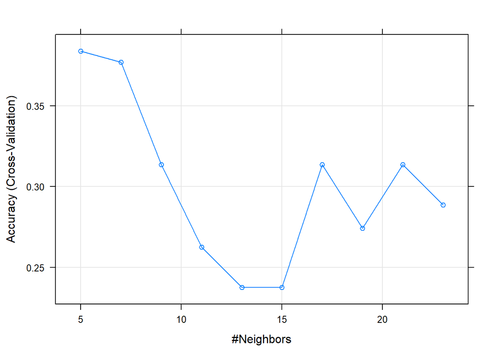

```r
knnMod <- train(Class_Type ~ .,
                method='knn', preProcess=c('center','scale'),
                tuneLength=10, trControl=trainControl(method='cv'), data=trainingSet)
plot(knnMod)
```

```r
predKNN <- predict(knnMod, testingSet)
```

```r
length=length(testingSet$Class_Type)

sumKNN <- sum(predKNN==testingSet$Class_Type)

accuracy_KNN <- sumKNN/length

predDF_3 <- data.frame(predKNN,
                      TYPE=testingSet$Class_Type)
accuracy_KNN
```

```
## [1] 0.5
```

The Random Forest algorithm, with differences by default than the random forest model in the caret package used previously.

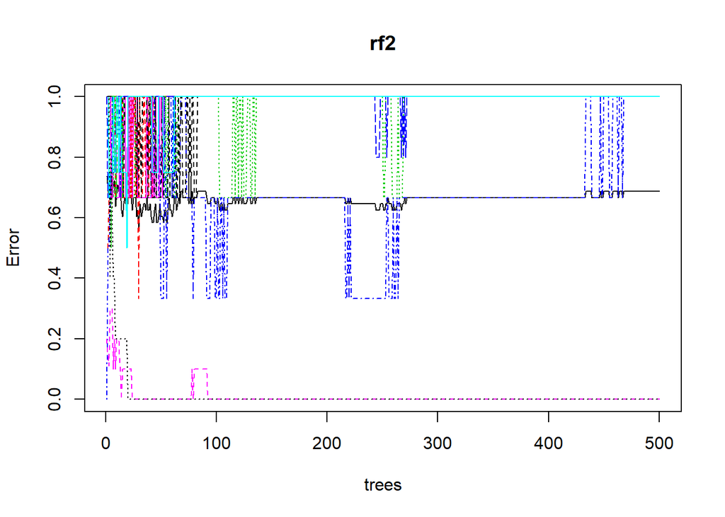

```r
rf2 <- randomForest(Class_Type~., data=trainingSet)

plot(rf2)
```

```r
predRF2 <- predict(rf2, testingSet, type='class')

sum <- sum(predRF2==testingSet$Class_Type)
accuracy_RF2 <- sum/length
accuracy_RF2
```

```
## [1] 0.6666667
```

Now, lets change the flu non immunized to ‘healthy’, the flu with antibiotics to its own class, the flu without antibiotics to its own class, combine the Hemo males and females, and keep the tetanis immunized as its own class. Then see how well the prediction accuracy improves.

```r
Hemo2 <- FHT_HemoOnly[grep('Hemo', FHT_HemoOnly$Class_Type),]
Hemo2$Class_Type <- 'Hemochromatosis'
FluAntb <- FHT_HemoOnly[grep('Flu Immunized Plus', FHT_HemoOnly$Class_Type),]
FluAntb$Class_Type <- 'Flu Vaccine and Antibiotics'
FluOnly <- FHT_HemoOnly[grep('Flu Immunized Only', FHT_HemoOnly$Class_Type),]
FluOnly$Class_Type <- 'Flu vaccinated only'
healthy <- FHT_HemoOnly[grep('healthy', FHT_HemoOnly$Class_Type),]
healthy$Class_Type <- 'healthy non-immunized 18-45 year olds'
tetn <- FHT_HemoOnly[grep('Tetan', FHT_HemoOnly$Class_Type),]

NewDataHemo_ML <- rbind(Hemo2,FluAntb,FluOnly,healthy,tetn)
unique(NewDataHemo_ML$Class_Type)
```

```
## [1] "Hemochromatosis"
## [2] "Flu Vaccine and Antibiotics"
## [3] "Flu vaccinated only"
## [4] "healthy non-immunized 18-45 year olds"
## [5] "Tetanis Immunized"
```

```r
inTrain <- createDataPartition(y=NewDataHemo_ML$Class_Type, p=0.7, list=FALSE)

trainingSet <- NewDataHemo_ML[inTrain,]
testingSet <- NewDataHemo_ML[-inTrain,]

set.seed(123)
write.csv(NewDataHemo_ML,'NewDataHemo_ML.csv', row.names=TRUE)
```

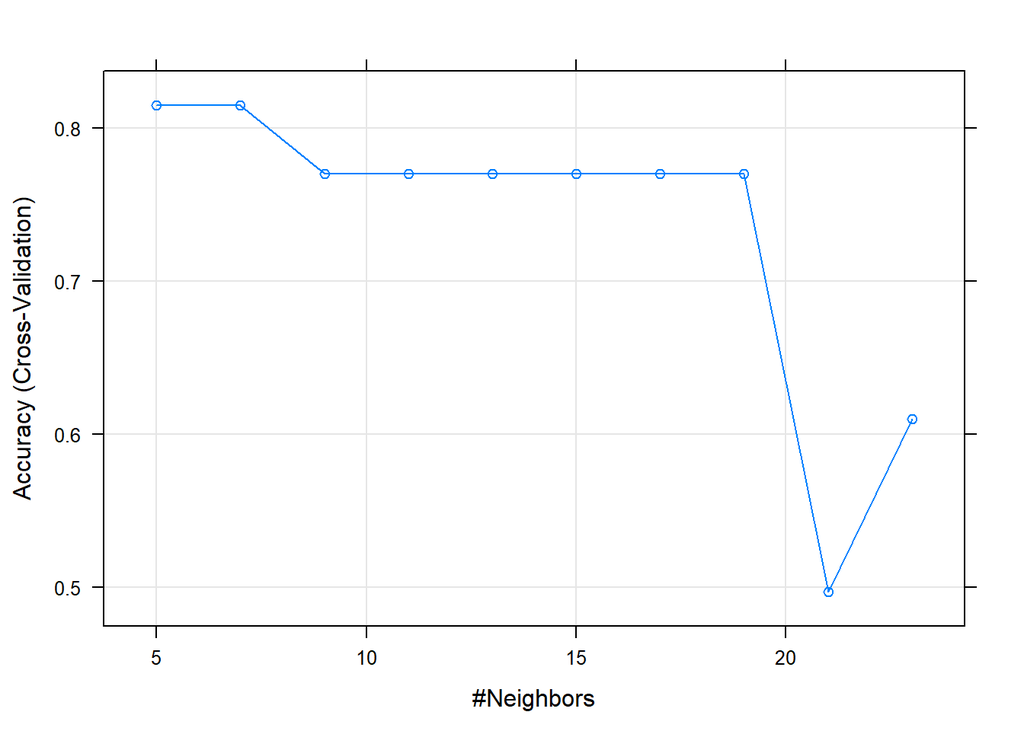

```r
knnMod <- train(Class_Type ~ .,
                method='knn', preProcess=c('center','scale'),
                tuneLength=10, trControl=trainControl(method='cv'), data=trainingSet)
plot(knnMod)
```

```r
predKNN <- predict(knnMod, testingSet)
```

```r
length=length(testingSet$Class_Type)

sumKNN <- sum(predKNN==testingSet$Class_Type)

accuracy_KNN <- sumKNN/length

predDF_3 <- data.frame(predKNN,
                      TYPE=testingSet$Class_Type)
accuracy_KNN
```

```
## [1] 0.9230769
```

The Random Forest algorithm, with differences by default than the random forest model in the caret package used previously.

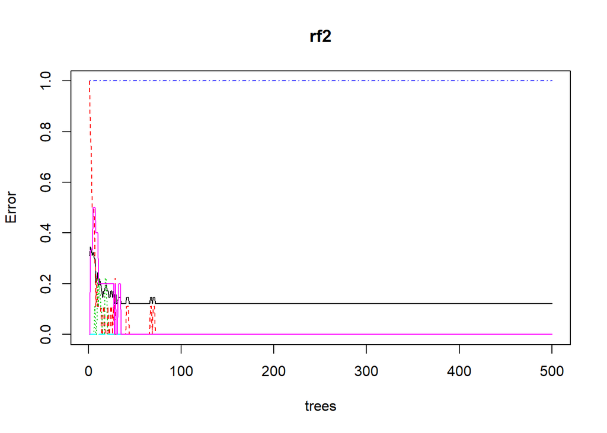

```r
trainingSet$Class_Type <- as.factor(trainingSet$Class_Type)
testingSet$Class_Type <- as.factor(testingSet$Class_Type)
rf2 <- randomForest(Class_Type~., data=trainingSet)

plot(rf2)
```

```r
predRF2 <- predict(rf2, testingSet, type='class')

sum <- sum(predRF2==testingSet$Class_Type)
accuracy_RF2 <- sum/length
accuracy_RF2
```

```
## [1] 0.9230769
```

Now use the H2O ML package.

```r
library(h2o)
h2o.init(nthreads=-1, max_mem_size="2G")
```

```
##  Connection successful!
##
## R is connected to the H2O cluster:
##     H2O cluster uptime:         44 minutes 12 seconds
##     H2O cluster timezone:       America/Los_Angeles
##     H2O data parsing timezone:  UTC
##     H2O cluster version:        3.28.0.2
##     H2O cluster version age:    11 days
##     H2O cluster name:           H2O_started_from_R_m_wkq150
##     H2O cluster total nodes:    1
##     H2O cluster total memory:   1.97 GB
##     H2O cluster total cores:    2
##     H2O cluster allowed cores:  2
##     H2O cluster healthy:        TRUE
##     H2O Connection ip:          localhost
##     H2O Connection port:        54321
##     H2O Connection proxy:       NA
##     H2O Internal Security:      FALSE
##     H2O API Extensions:         Amazon S3, Algos, AutoML, Core V3, TargetEncoder, Core V4
##     R Version:                  R version 3.6.2 (2019-12-12)
```

```r
h2o.removeAll() ## clean slate - just in case the cluster was already running

D = h2o.importFile(path = normalizePath("NewDataHemo_ML.csv"))
#h2o.summary(D) would print the summary stats of these 251 features

data = h2o.splitFrame(D,ratios=c(.7,.15),
                      destination_frames = c("train","test","valid"))
names(data) <- c('Train','Test','Valid')
```

multinomial model

```r
m1 = h2o.glm(training_frame = data$Train, validation_frame = data$Valid,
             x = colnames(data$Train)[2:74],
             y = 'Class_Type',
             family='multinomial',
             solver='L_BFGS')
h2o.confusionMatrix(m1, valid=TRUE)
```

|  | Flu Vaccine and Antibiotics | Flu vaccinated only | Hemochromatosis | Tetanis Immunized | healthy non-immunized 18-45 year olds | Error | Rate |
| --- | --- | --- | --- | --- | --- | --- | --- |
| Flu Vaccine and Antibiotics | 2 | 0 | 0 | 0 | 0 | 0.00000000 | 0 / 2 |
| Flu vaccinated only | 0 | 3 | 0 | 0 | 0 | 0.00000000 | 0 / 3 |
| Hemochromatosis | 0 | 0 | 5 | 0 | 0 | 0.00000000 | 0 / 5 |
| Tetanis Immunized | 1 | 0 | 0 | 0 | 0 | 1.00000000 | 1 / 1 |
| healthy non-immunized 18-45 year olds | 0 | 0 | 0 | 0 | 0 | NaN | 0 / 0 |
| Totals | 3 | 3 | 5 | 0 | 0 | 0.09090909 | 1 / 11 |

```r
2/11
```

```
## [1] 0.1818182
```

```r
9/11
```

```
## [1] 0.8181818
```